# WECARE only PCA

AL

27/01/2021

# Summary

PCA for wecare-only (b37) wes dataset w/o Danish:

- Detects the same outliers as the previous analyses: **P5_E09** and possibly **P6_D05**, P1_C12, P1_D08, P5_E02
- Shows no irregularities in PCA analysis
- Provides evidence for using top 2 PC-s in regression model

**To clarify**

An e-mail was sent to bigsnpr package author:

- Why U-values (eigenvectors?) are numerically different from PC-s plotted by "scores" plot?
- How can I plot lines +/- 6xSD on my "scores" plot?
- I use eigenvectors in regression models to correct for population stratification; can I use U-values directly or should I scale it as you do in the "scores" plot?

**References**

- Preve 2018 pre-processing
- Preve 2020 PCA scripts: https://privefl.github.io/bigsnpr/articles/bedpca.html
- https://privefl.github.io/bigsnpr/articles/demo.html

# Start section

```r
# Time
Sys.time()
```

```
## [1] "2021-01-27 17:10:57 GMT"
```

```r
# Memory
gc()
```

```
##          used (Mb) gc trigger (Mb) limit (Mb) max used (Mb)
## Ncells 412030 22.1     856470 45.8         NA   641517 34.3
## Vcells 790491  6.1    8388608 64.0      16384  1768563 13.5
```

```r
# Clean up
rm(list=ls())
graphics.off()

# Options
options(stringsAsFactors = F)

# Working folders
base_folder <- "/Users/alexey/Documents" # mac
project_folder <- file.path(base_folder,"wecare","final_analysis_2021","reanalysis_wo_danish_2021") # mac

scripts_folder <- file.path(project_folder,"scripts","s07_relatedness_and_pca")
setwd(scripts_folder)

data_folder <- file.path(project_folder,"data","s07_relatedness_and_pca")

library(bigsnpr) # for bed_autoSVD() and bed()
library(bigutilsr) # for prob_dist() and tukey_mc_up() for outlier detection
library(hexbin) # for plotting svd loadings
library(ggplot2)
library(dplyr)
NCORES <- 1
#NCORES <- nb_cores() # 2
```

# Read bed-bim-fam file-set

```r
# Location of bed file
bed_file <- file.path(data_folder,"s03_non_related","common_biallelic_autosomal_snps_in_HWE_norel.bed")

# Attach PLINK data to R environment
wecare.bed <- bed(bed_file) # bigsnpr::bed

# Explore wecare.bed
wecare.bed
```

```
## A 'bed' object with 335 samples and 36565 variants.
```

```r
names(wecare.bed)
```

```
##  [1] ".->bedfile"   "light"        ".self"        ".->.map"      "show"         "extptr"       "nrow"         "bimfile"      ".refClassDef" "bedfile"      "ncol"         "initialize"   "map"          "fam"          ".map"         ".->extptr"    "famfile"      ".fam"         "address"      ".->.fa…
```

```r
#attributes(wecare.bed)
#str(wecare.bed)
#wecare.bed$bedfile
#wecare.bed$address

# Clean-up
rm(bed_file)
```

# Phenotypes

```r
# Phenotypes from plink
wecare_fam.df <- wecare.bed$fam
dim(wecare_fam.df)
```

```
## [1] 335   6
```

```r
head(wecare_fam.df)
```

```
##   family.ID sample.ID paternal.ID maternal.ID sex affection
## 1    P1_A01    P1_A01           0           0   2         2
## 2    P1_A02    P1_A02           0           0   2         2
## 3    P1_A03    P1_A03           0           0   2         2
## 4    P1_A04    P1_A04           0           0   2         2
## 5    P1_A05    P1_A05           0           0   2         2
## 6    P1_A06    P1_A06           0           0   2         2
```

```r
# Phenotypes from the main dataset file
load(file.path(project_folder,"data","s06_qc_filters","s04_filter_by_sample_call_rates.RData"))
rm(genotypes.mx,variants.df)

# Update folders
base_folder <- "/Users/alexey/Documents"
project_folder <- file.path(base_folder,"wecare","final_analysis_2021","reanalysis_wo_danish_2021")
scripts_folder <- file.path(project_folder,"scripts","s07_relatedness_and_pca")
data_folder <- file.path(project_folder,"data","s07_relatedness_and_pca")

dim(phenotypes.df)
```

```
## [1] 335  40
```

```r
#str(phenotypes.df)
#table(phenotypes.df$filter)
#phenotypes.df[phenotypes.df$filter=="eigenvectors_outlier","wes_id"]
#"Possibly_related_to_P1-D05" -> phenotypes.df[phenotypes.df$wes_id=="P5_C12","filter"]

# Merge fam-file and phenotypes from the main dataset (removing samples that are not in fam-file)
wecare_phenotypes.df <- left_join(wecare_fam.df, phenotypes.df,
                                  by=c("sample.ID"="wes_id"))
dim(wecare_phenotypes.df)
```

```
## [1] 335  45
```

```r
colnames(wecare_phenotypes.df)
```

```
##  [1] "family.ID"      "sample.ID"      "paternal.ID"    "maternal.ID"    "sex"            "affection"      "gwas_id"        "merged_id"      "filter"         "cc"             "setno"          "registry"       "family_history" "age_dx"         "age_ref"        "rstime"         "eig1_gwas"      "ei…
```

```r
#sum(wecare_phenotypes.df$sample.ID == "P5_C12")

# Make sure that dplyr::left_joint hasnt changed the order of samples
sum(substr(wecare_phenotypes.df$merged_id,1,6) != wecare_fam.df$sample.ID)
```

```
## [1] 0
```

```r
# Add column fopr outliers
wecare_phenotypes.df <- data.frame(wecare_phenotypes.df,outlier=F)

# Clean-up
rm(phenotypes.df, wecare_fam.df)
```

# Variants

Data from bed-bim-fam only: explored; is it needed for calculation??

```r
# map file
wecare_map.df <- wecare.bed$map
dim(wecare_map.df)
```

```
## [1] 36565     6
```

```r
head(wecare_map.df)
```

```
##   chromosome    marker.ID genetic.dist physical.pos allele1 allele2
## 1          1 1_881627_G_A            0       881627       G       A
## 2          1 1_897325_G_C            0       897325       G       C
## 3          1 1_897564_T_C            0       897564       T       C
## 4          1 1_897738_C_T            0       897738       T       C
## 5          1 1_911916_C_T            0       911916       T       C
## 6          1 1_982941_T_C            0       982941       T       C
```

```r
# make simple counts
wecare_maf.df <- bed_MAF(wecare.bed)
dim(wecare_maf.df)
```

```
## [1] 36565     5
```

```r
head(wecare_maf.df)
```

```
##    ac mac         af        maf   N
## 1 196 196 0.33793103 0.33793103 290
## 2  42  42 0.07266436 0.07266436 289
## 3  43  43 0.06847134 0.06847134 314
## 4  41  41 0.07093426 0.07093426 289
## 5  85  85 0.12724551 0.12724551 334
## 6  61  61 0.09327217 0.09327217 327
```

```r
# merge map file with the counts
wecare_variants.df <- cbind(wecare_map.df,wecare_maf.df)
dim(wecare_variants.df)
```

```
## [1] 36565    11
```

```r
head(wecare_variants.df)
```

```
##   chromosome    marker.ID genetic.dist physical.pos allele1 allele2  ac mac         af        maf   N
## 1          1 1_881627_G_A            0       881627       G       A 196 196 0.33793103 0.33793103 290
## 2          1 1_897325_G_C            0       897325       G       C  42  42 0.07266436 0.07266436 289
## 3          1 1_897564_T_C            0       897564       T       C  43  43 0.06847134 0.06847134 314
## 4          1 1_897738_C_T            0       897738       T       C  41  41 0.07093426 0.07093426 289
## 5          1 1_911916_C_T            0       911916       T       C  85  85 0.12724551 0.12724551 334
## 6          1 1_982941_T_C            0       982941       T       C  61  61 0.09327217 0.09327217 327
```

```r
# Variants with AF(ref) < AF(alt)
inverted <- wecare_variants.df$ac != wecare_variants.df$mac
sum(inverted)
```

```
## [1] 0
```

```r
#wecare_variants.df[inverted,]

# Clean-up
rm(wecare_map.df, wecare_maf.df, inverted)
```

# PCA

Could be sequentially repeated if outliers are detected

## 1st round

Takes care about LD etc.  
See ?plot.big_SVD for plotting svd objets.

```r
# Get indices of non-outliers in format required by bed_autoSVD
# (integer indices, indicating row numbers)
non_outliers1 <- which(!wecare_phenotypes.df$outlier)
length(non_outliers1)
```

```
## [1] 335
```

```r
# bigsnpr::bed_autoSVD, Default k = 10
#using non-outlier samples (ind.row) and all variants (ind.col)
#table(wecare.bed$map$chromosome) - if complains abotut non-numeric chromosomes
wecare.svd1 <- bed_autoSVD(wecare.bed,
                          ind.row=non_outliers1,
                          ncores = NCORES)
```

```
##
## Phase of clumping (on MAC) at r^2 > 0.2.. keep 16917 variants.
## Discarding 0 variant with MAC < 10.
##
## Iteration 1:
## Computing SVD..
## 115 outlier variants detected..
## 1 long-range LD region detected..
##
## Iteration 2:
## Computing SVD..
## 16 outlier variants detected..
## 0 long-range LD region detected..
##
## Iteration 3:
## Computing SVD..
## 0 outlier variant detected..
##
## Converged!
```

```r
#ind.col=vars_not_in_LD,

# Variants not in LD (detected by clumping during autoSVD)
vars_not_in_LD1 <- attr(wecare.svd1, "subset")
length(vars_not_in_LD1)
```

```
## [1] 16786
```

```r
#attributes(wecare.svd)
str(wecare.svd1)
```

```
## List of 7
##  $ d     : num [1:10] 190 178 148 148 147 ...
##  $ u     : num [1:335, 1:10] 0.13867 0.14457 -0.00914 -0.02042 -0.0273 ...
##  $ v     : num [1:16786, 1:10] 0.000899 -0.004971 0.005014 0.007452 -0.00957 ...
##  $ niter : num 13
##  $ nops  : num 222
##  $ center: num [1:16786] 0.676 0.137 0.254 0.211 0.511 ...
##  $ scale : num [1:16786] 0.669 0.357 0.471 0.435 0.617 ...
##  - attr(*, "class")= chr "big_SVD"
##  - attr(*, "subset")= int [1:16786] 1 3 5 9 10 11 12 15 16 20 ...
##  - attr(*, "lrldr")='data.frame':    1 obs. of  3 variables:
##   ..$ Chr  : int 6
##   ..$ Start: int 32632777
##   ..$ Stop : int 41318438
```

```r
# Eigenvalues
length(wecare.svd1$d)
```

```
## [1] 10
```

```r
wecare.svd1$d
```

```
##  [1] 190.4161 178.1881 148.2474 147.8966 147.4755 147.3171 146.9720 146.9220 146.5112 146.1819
```

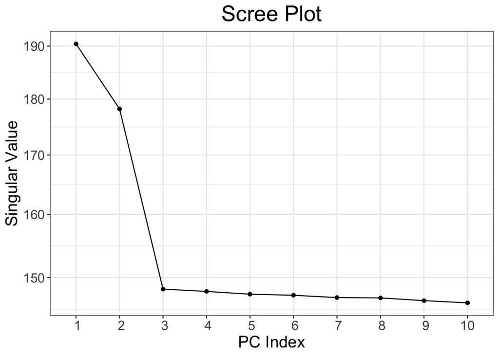

```r
plot(wecare.svd1) # default type="screeplot" see ?plot.big_SVD
```

```r
# Eigenvectors
dim(wecare.svd1$u)
```

```
## [1] 335  10
```

```r
head(wecare.svd1$u)
```

```
##              [,1]         [,2]        [,3]        [,4]        [,5]         [,6]        [,7]         [,8]        [,9]       [,10]
## [1,]  0.138669030  0.103178270 -0.07197718 -0.01470916 -0.07142627 -0.048621923 -0.05548467 -0.120196751 -0.02066855  0.04271191
## [2,]  0.144570855  0.063452138  0.03791468  0.01832963  0.01495920 -0.007054916 -0.03243462 -0.016748795 -0.03312423 -0.02070197
## [3,] -0.009143547 -0.005809375 -0.03899057  0.01481835  0.02749890 -0.108040469 -0.01044647  0.007756526  0.01514653 -0.04549978
## [4,] -0.020422428  0.021195866  0.06120590 -0.02802932 -0.01855846  0.015608371  0.05124295  0.045740968  0.03566837 -0.01950312
## [5,] -0.027297881 -0.025564221  0.02862236 -0.04235041  0.07595330 -0.021613558 -0.08057521  0.004165515  0.00138122  0.02896001
## [6,] -0.012743365 -0.013017876 -0.04378360 -0.09381667 -0.06758309  0.002568256  0.02148264 -0.082163836  0.12031314 -0.06652842
```

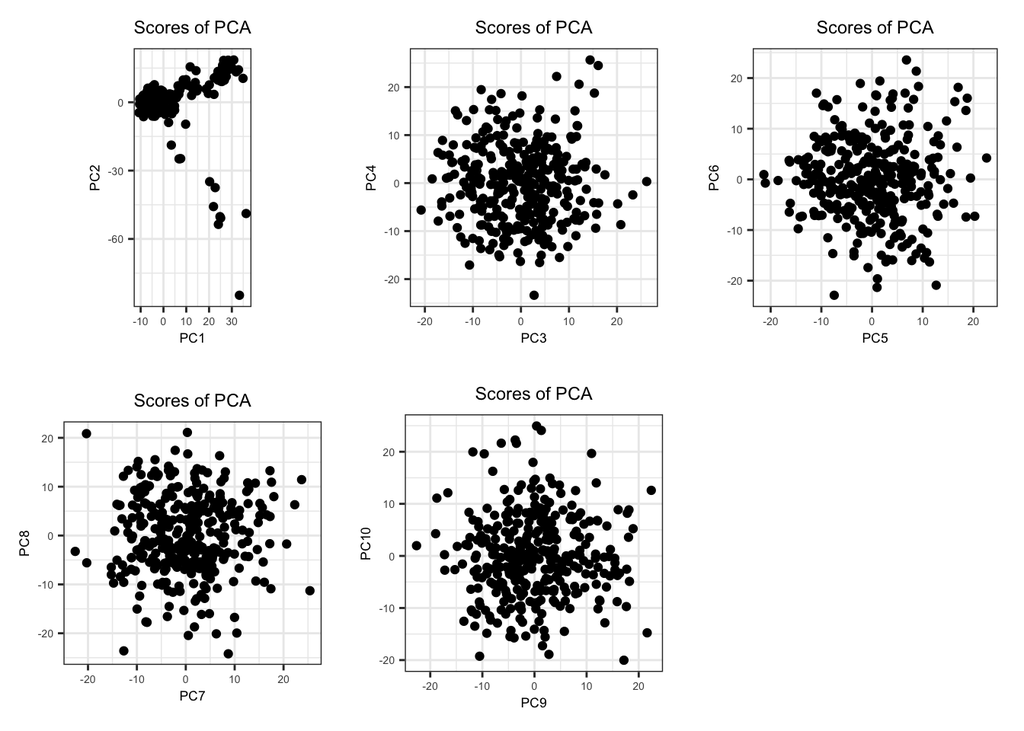

```r
# PCA summary (for PCs from 1 to 10)
plot(wecare.svd1,type = "scores",scores=1:10,coeff=0.4)
```

```r
# Loadings
dim(wecare.svd1$v)
```

```
## [1] 16786    10
```

```r
head(wecare.svd1$v)
```

```
##               [,1]         [,2]          [,3]         [,4]         [,5]         [,6]         [,7]          [,8]          [,9]         [,10]
## [1,]  0.0008985564 -0.001365840  0.0074649402  0.005474951  0.011671661 -0.003025119  0.006593476 -0.0114618804 -0.0174175875 -0.0033920430
## [2,] -0.0049710874  0.004488474  0.0103785079  0.008392403 -0.007417950 -0.003798040  0.003740992  0.0004753363 -0.0006344678 -0.0024664248
## [3,]  0.0050137213  0.002469776  0.0048288435  0.011599665  0.014017082  0.000750906  0.010391508 -0.0060232296 -0.0167692956  0.0009021118
## [4,]  0.0074515986  0.001992729 -0.0072453340 -0.004987653  0.010036058 -0.002726673 -0.002664380 -0.0009837849  0.0048035537 -0.0025986727
## [5,] -0.0095703011  0.005151878 -0.0008142444 -0.001156628 -0.011318217  0.003908498  0.007543729  0.0048508093 -0.0019126295  0.0018379164
## [6,]  0.0085688485 -0.019976287 -0.0167882307 -0.001421225 -0.007926717 -0.005121912 -0.006352471  0.0176084509  0.0127812426 -0.0052314787
```

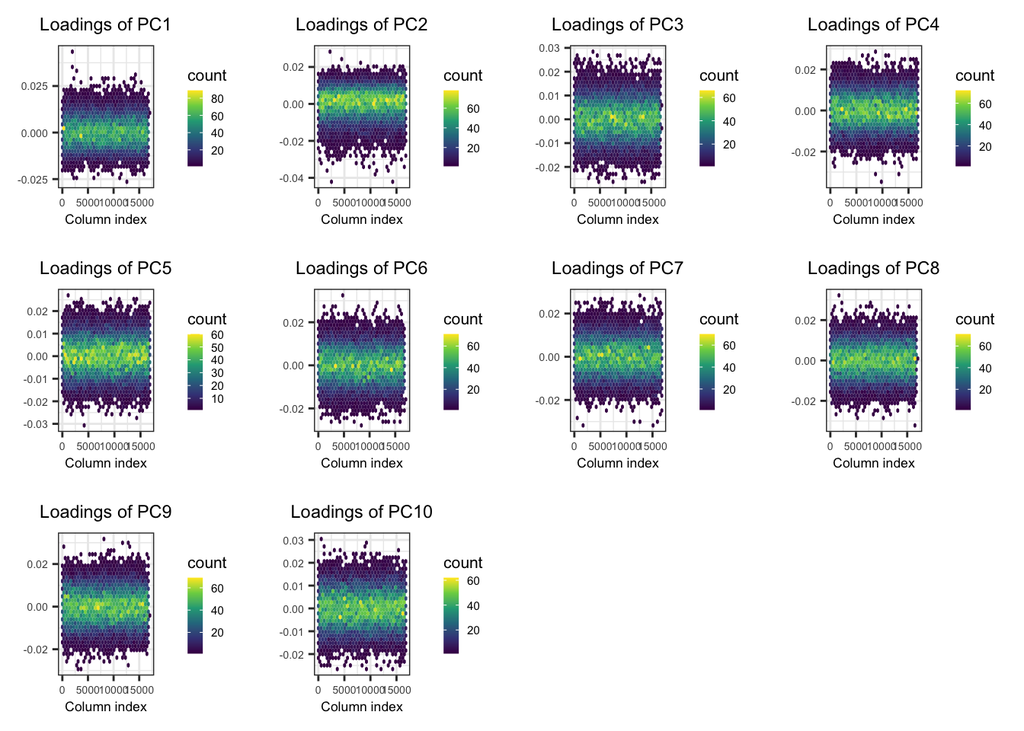

```r
# Loadings summary (for PCs from 1 to 10)
plot(wecare.svd1,type="loadings",loadings=1:10,coeff=0.4)
```

```r
# Calculate a measure of "outlieness"
U1 <- wecare.svd1$u
prob1 <- prob_dist(U1, ncores=NCORES) # bigutilsr::prob_dist
S1 <- prob1$dist.self / sqrt(prob1$dist.nn)
tukey_threshold1 <- tukey_mc_up(S1) # bigutilsr::tukey_mc_up

# Outliers
outliers1 <- S1 >= tukey_threshold1
sum(outliers1)
```

```
## [1] 0
```

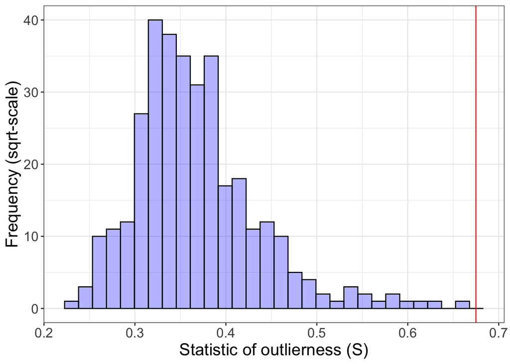

```r
#outliers_id1 <- wecare.bed$fam$sample.ID[S1 >= tukey_threshold1]
#outliers_id1

# Histogram by "outlieness" score
ggplot() +
  geom_histogram(aes(S1), color = "black", fill = "blue", alpha = 0.3) +
  theme_bigstatsr() +
  geom_vline(xintercept=tukey_threshold1, colour="red") +
  labs(x = "Statistic of outlierness (S)", y = "Frequency (sqrt-scale)")
```

```r
# Location of outlier(s) in PCA plots
#plot(U1[, 1:2], col = (S1 > tukey_threshold1) + 1, pch = 20)
#plot(U1[, 3:4], col = (S1 > tukey_threshold1) + 1, pch = 20)
#plot(U1[, 5:6], col = (S1 > tukey_threshold1) + 1, pch = 20)

# Add outlier to the phenotypes data frame
#wecare_phenotypes.df$outlier <- wecare_phenotypes.df$outlier |
#  wecare_phenotypes.df$sample.ID %in% outliers_id1

#sum(wecare_phenotypes.df$outlier)

# Clean-up
rm(non_outliers1,U1,prob1,S1,tukey_threshold1,
   outliers1,vars_not_in_LD1) #wecare.svd1, vars_not_in_LD1, outliers_id1
```

## 2nd round

**Omitted because of no outliers**

Re-run w/o previously detected outlier(s)  
Using previously calculated vars_not_in_LD to speed-up  
https://privefl.github.io/bigsnpr/articles/bedpca.html

## 3rd round

**Omitted because of no outliers**

Re-run w/o previously detected outlier(s)  
Using previously calculated vars_not_in_LD to speed-up

https://privefl.github.io/bigsnpr/articles/bedpca.html

# Update phenotypes table

```r
phenotypes_with_PCs.df <- wecare_phenotypes.df[!wecare_phenotypes.df$outlier,]
dim(phenotypes_with_PCs.df)
```

```
## [1] 335  46
```

```r
#eigenvectors.mx <- wecare.svd3$u
eigenvectors.mx <- wecare.svd1$u
dim(eigenvectors.mx)
```

```
## [1] 335  10
```

```r
colnames(eigenvectors.mx) <-
  c("pc1","pc2","pc3","pc4","pc5","pc6","pc7","pc8","pc9","pc10")

phenotypes_with_PCs.df <- cbind(phenotypes_with_PCs.df, eigenvectors.mx)
dim(phenotypes_with_PCs.df)
```

```
## [1] 335  56
```

```r
colnames(phenotypes_with_PCs.df)
```

```
##  [1] "family.ID"      "sample.ID"      "paternal.ID"    "maternal.ID"    "sex"            "affection"      "gwas_id"        "merged_id"      "filter"         "cc"             "setno"          "registry"       "family_history" "age_dx"         "age_ref"        "rstime"         "eig1_gwas"      "ei…
```

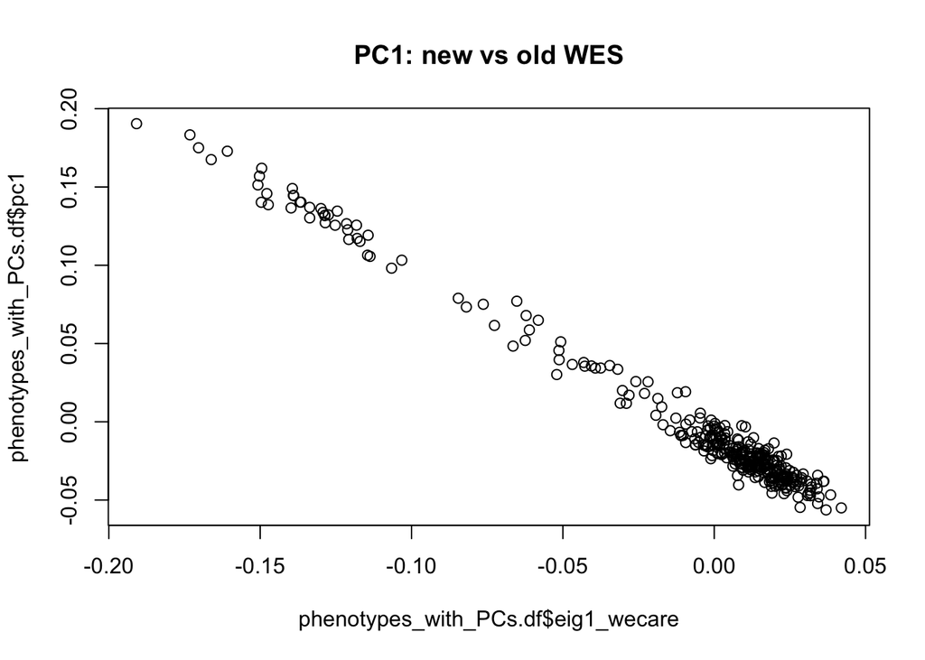

```r
# Check consistency with the previous eigenvectors from WES
plot(phenotypes_with_PCs.df$eig1_wecare,
     phenotypes_with_PCs.df$pc1,main="PC1: new vs old WES")
```

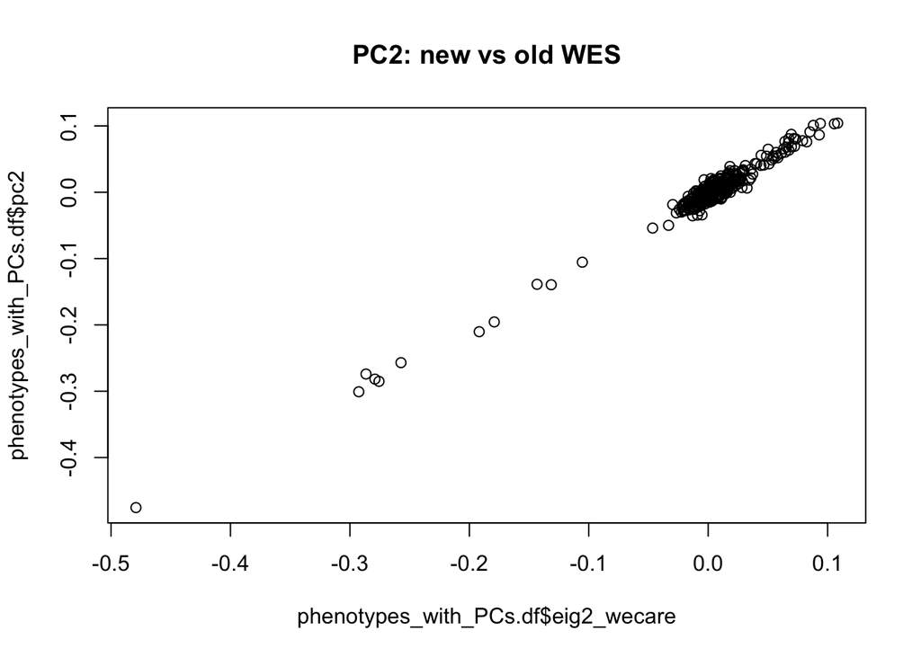

```r
plot(phenotypes_with_PCs.df$eig2_wecare,
     phenotypes_with_PCs.df$pc2,main="PC2: new vs old WES")
```

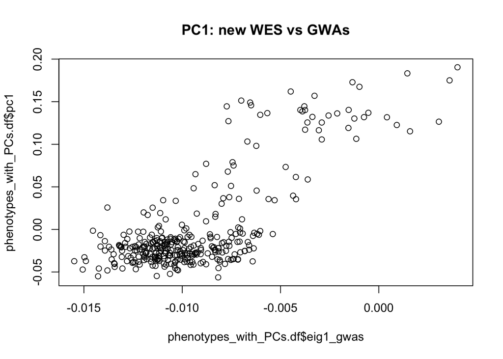

```r
# Check consistency with the previous eigenvectors from GWAS
plot(phenotypes_with_PCs.df$eig1_gwas,
     phenotypes_with_PCs.df$pc1,main="PC1: new WES vs GWAs")
```

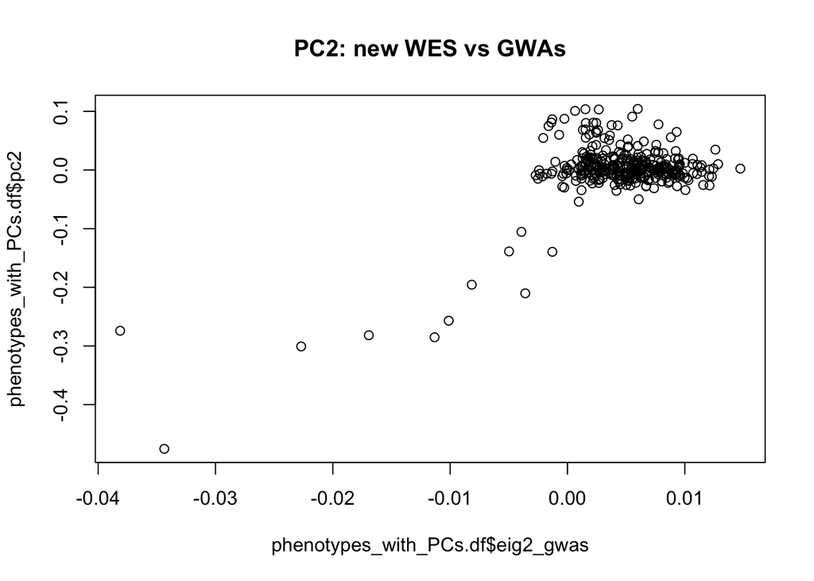

```r
plot(phenotypes_with_PCs.df$eig2_gwas,
     phenotypes_with_PCs.df$pc2,main="PC2: new WES vs GWAs")
```

```r
# Clean-up
rm(wecare_phenotypes.df, eigenvectors.mx) # vars_not_in_LD1
#somehow close wecare.bed ?
```

# Calculate PC-outliers by SD

P6_D05 and P5_E09 are clear outliers when projected to 1kgp

## 6x sd

```r
sd_threshold <- 6

# PC1 outliers
pc1 <- phenotypes_with_PCs.df$pc1
pc1_mean <- mean(pc1)
pc1_sd  <- sd(pc1)
lo_pc1 <- pc1 < pc1_mean - sd_threshold * pc1_sd
hi_pc1 <- pc1 > pc1_mean + sd_threshold * pc1_sd

cat("pc1 lo/hi:",sum(lo_pc1),"/",sum(hi_pc1),"\n")
```

```
## pc1 lo/hi: 0 / 0
```

```r
phenotypes_with_PCs.df$sample.ID[lo_pc1]
```

```
## character(0)
```

```r
phenotypes_with_PCs.df$sample.ID[hi_pc1]
```

```
## character(0)
```

```r
# PC2 outliers
pc2 <- phenotypes_with_PCs.df$pc2
pc2_mean <- mean(pc2)
pc2_sd  <- sd(pc2)
lo_pc2 <- pc2 < pc2_mean - sd_threshold * pc2_sd
hi_pc2 <- pc2 > pc2_mean + sd_threshold * pc2_sd

cat("pc2 lo/hi:",sum(lo_pc2),"/",sum(hi_pc2),"\n")
```

```
## pc2 lo/hi: 1 / 0
```

```r
phenotypes_with_PCs.df$sample.ID[lo_pc2]
```

```
## [1] "P5_E09"
```

```r
phenotypes_with_PCs.df$sample.ID[hi_pc2]
```

```
## character(0)
```

```r
rm(sd_threshold,
   pc1, pc1_mean, pc1_sd, lo_pc1, hi_pc1,
   pc2, pc2_mean, pc2_sd, lo_pc2, hi_pc2)
```

## 5x sd

```r
sd_threshold <- 5

# PC1 outliers
pc1 <- phenotypes_with_PCs.df$pc1
pc1_mean <- mean(pc1)
pc1_sd  <- sd(pc1)
lo_pc1 <- pc1 < pc1_mean - sd_threshold * pc1_sd
hi_pc1 <- pc1 > pc1_mean + sd_threshold * pc1_sd

cat("pc1 lo/hi:",sum(lo_pc1),"/",sum(hi_pc1),"\n")
```

```
## pc1 lo/hi: 0 / 0
```

```r
phenotypes_with_PCs.df$sample.ID[lo_pc1]
```

```
## character(0)
```

```r
phenotypes_with_PCs.df$sample.ID[hi_pc1]
```

```
## character(0)
```

```r
# PC2 outliers
pc2 <- phenotypes_with_PCs.df$pc2
pc2_mean <- mean(pc2)
pc2_sd  <- sd(pc2)
lo_pc2 <- pc2 < pc2_mean - sd_threshold * pc2_sd
hi_pc2 <- pc2 > pc2_mean + sd_threshold * pc2_sd

cat("pc2 lo/hi:",sum(lo_pc2),"/",sum(hi_pc2),"\n")
```

```
## pc2 lo/hi: 5 / 0
```

```r
phenotypes_with_PCs.df$sample.ID[lo_pc2]
```

```
## [1] "P1_C12" "P1_D08" "P5_E02" "P5_E09" "P6_D05"
```

```r
phenotypes_with_PCs.df$sample.ID[hi_pc2]
```

```
## character(0)
```

```r
rm(sd_threshold,
   pc1, pc1_mean, pc1_sd, lo_pc1, hi_pc1,
   pc2, pc2_mean, pc2_sd, lo_pc2, hi_pc2)
```

## 4x sd

```r
sd_threshold <- 4

# PC1 outliers
pc1 <- phenotypes_with_PCs.df$pc1
pc1_mean <- mean(pc1)
pc1_sd  <- sd(pc1)
lo_pc1 <- pc1 < pc1_mean - sd_threshold * pc1_sd
hi_pc1 <- pc1 > pc1_mean + sd_threshold * pc1_sd

cat("pc1 lo/hi:",sum(lo_pc1),"/",sum(hi_pc1),"\n")
```

```
## pc1 lo/hi: 0 / 0
```

```r
phenotypes_with_PCs.df$sample.ID[lo_pc1]
```

```
## character(0)
```

```r
phenotypes_with_PCs.df$sample.ID[hi_pc1]
```

```
## character(0)
```

```r
# PC2 outliers
pc2 <- phenotypes_with_PCs.df$pc2
pc2_mean <- mean(pc2)
pc2_sd  <- sd(pc2)
lo_pc2 <- pc2 < pc2_mean - sd_threshold * pc2_sd
hi_pc2 <- pc2 > pc2_mean + sd_threshold * pc2_sd

cat("pc2 lo/hi:",sum(lo_pc2),"/",sum(hi_pc2),"\n")
```

```
## pc2 lo/hi: 6 / 0
```

```r
phenotypes_with_PCs.df$sample.ID[lo_pc2]
```

```
## [1] "P1_C05" "P1_C12" "P1_D08" "P5_E02" "P5_E09" "P6_D05"
```

```r
phenotypes_with_PCs.df$sample.ID[hi_pc2]
```

```
## character(0)
```

```r
rm(sd_threshold,
   pc1, pc1_mean, pc1_sd, lo_pc1, hi_pc1,
   pc2, pc2_mean, pc2_sd, lo_pc2, hi_pc2)
```

## 3x sd

```r
sd_threshold <- 3

# PC1 outliers
pc1 <- phenotypes_with_PCs.df$pc1
pc1_mean <- mean(pc1)
pc1_sd  <- sd(pc1)
lo_pc1 <- pc1 < pc1_mean - sd_threshold * pc1_sd
hi_pc1 <- pc1 > pc1_mean + sd_threshold * pc1_sd

cat("pc1 lo/hi:",sum(lo_pc1),"/",sum(hi_pc1),"\n")
```

```
## pc1 lo/hi: 0 / 5
```

```r
phenotypes_with_PCs.df$sample.ID[lo_pc1]
```

```
## character(0)
```

```r
phenotypes_with_PCs.df$sample.ID[hi_pc1]
```

```
## [1] "P1_E06" "P3_C03" "P3_C06" "P5_E09" "P6_D05"
```

```r
# PC2 outliers
pc2 <- phenotypes_with_PCs.df$pc2
pc2_mean <- mean(pc2)
pc2_sd  <- sd(pc2)
lo_pc2 <- pc2 < pc2_mean - sd_threshold * pc2_sd
hi_pc2 <- pc2 > pc2_mean + sd_threshold * pc2_sd

cat("pc2 lo/hi:",sum(lo_pc2),"/",sum(hi_pc2),"\n")
```

```
## pc2 lo/hi: 8 / 0
```

```r
phenotypes_with_PCs.df$sample.ID[lo_pc2]
```

```
## [1] "P1_C05" "P1_C09" "P1_C12" "P1_D08" "P2_E06" "P5_E02" "P5_E09" "P6_D05"
```

```r
phenotypes_with_PCs.df$sample.ID[hi_pc2]
```

```
## character(0)
```

```r
rm(sd_threshold,
   pc1, pc1_mean, pc1_sd, lo_pc1, hi_pc1,
   pc2, pc2_mean, pc2_sd, lo_pc2, hi_pc2)
```

# Detailed PCA plots

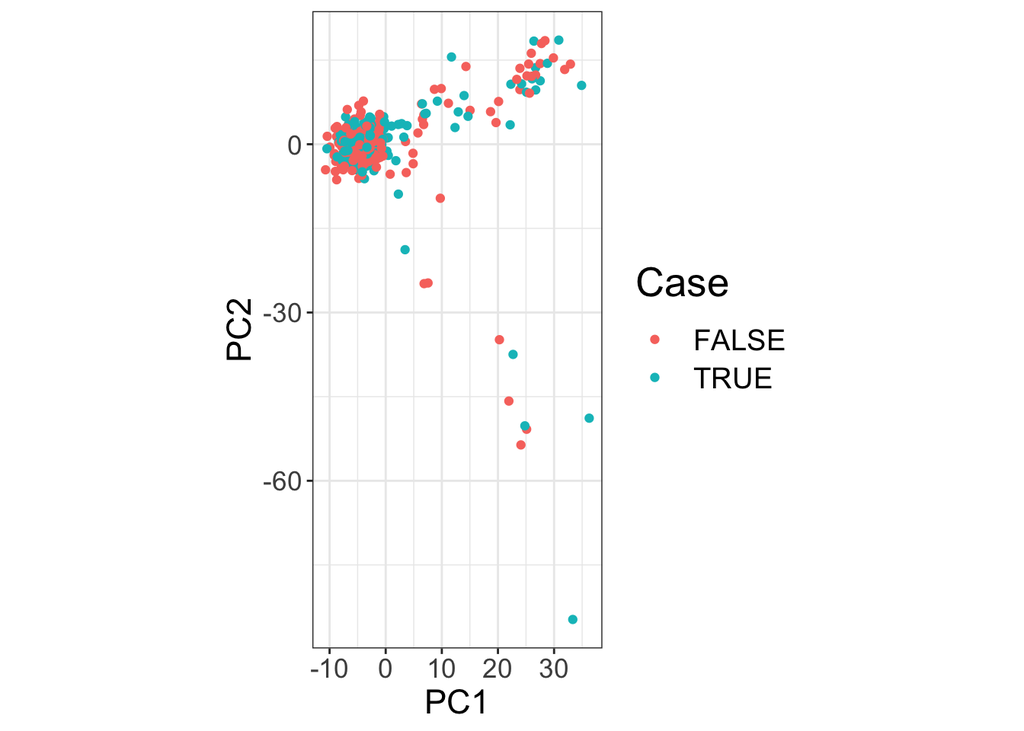

```r
plot(wecare.svd1, type = "scores") +
     aes(color = phenotypes_with_PCs.df$affection == 2) +
     labs(title = NULL, color = "Case")
```

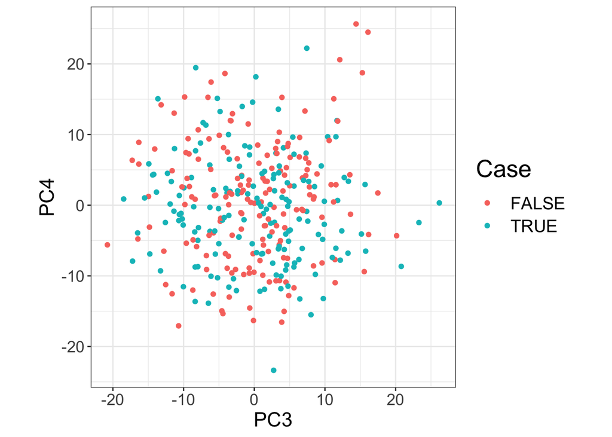

```r
# + geom_hline(pc2_mean - sd_threshold * pc2_sd,
#              linetype="dashed", color = "red")

plot(wecare.svd1, type = "scores", scores=3:4) +
     aes(color = phenotypes_with_PCs.df$affection == 2) +
     labs(title = NULL, color = "Case")
```

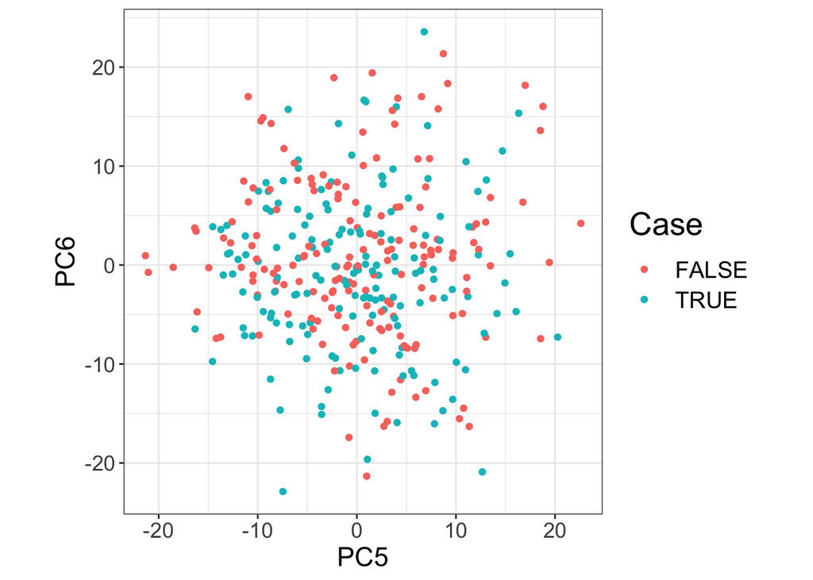

```r
plot(wecare.svd1, type = "scores", scores=5:6) +
     aes(color = phenotypes_with_PCs.df$affection == 2) +
     labs(title = NULL, color = "Case")
```

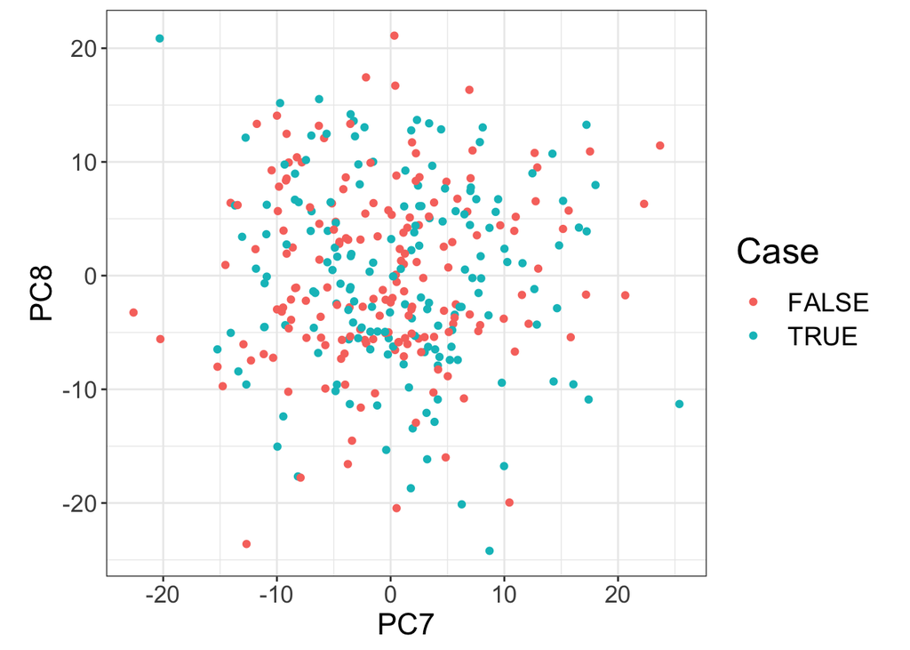

```r
plot(wecare.svd1, type = "scores", scores=7:8) +
     aes(color = phenotypes_with_PCs.df$affection == 2) +
     labs(title = NULL, color = "Case")
```

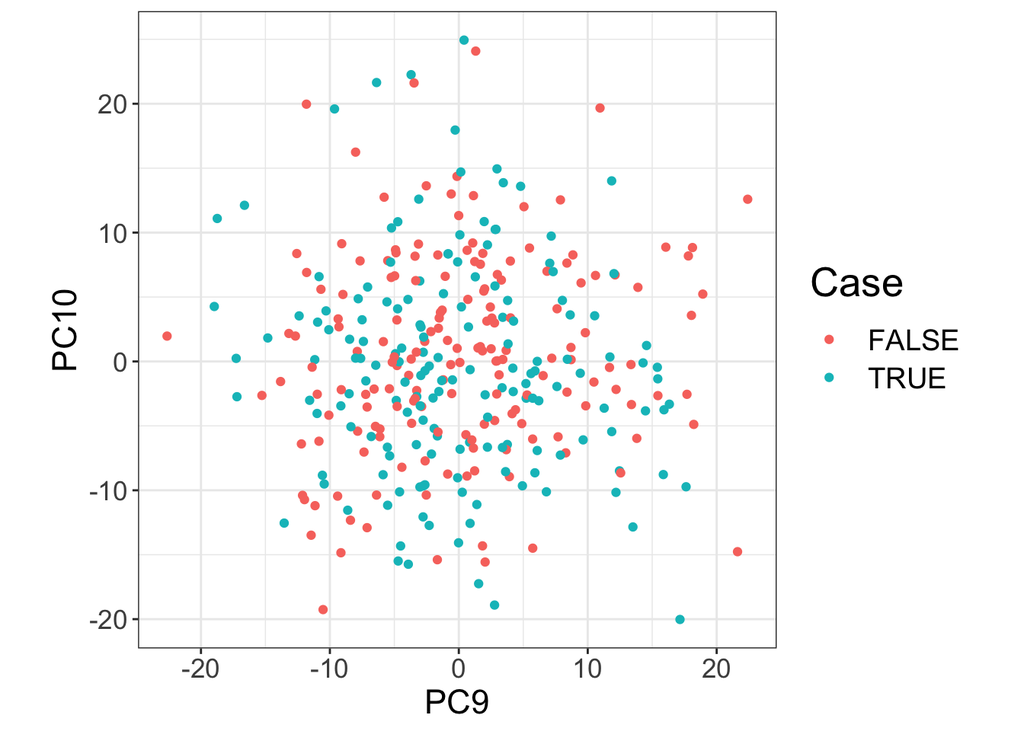

```r
plot(wecare.svd1, type = "scores", scores=9:10) +
     aes(color = phenotypes_with_PCs.df$affection == 2) +
     labs(title = NULL, color = "Case")
```

# Save results

```r
save.image(file.path(data_folder,"s04_calculate_PCs.RData"))
save(phenotypes_with_PCs.df,file=file.path(data_folder,"s04_phenotypes_with_PCs.RData"))
```

# End section

```r
ls()
```

```
## [1] "base_folder"            "data_folder"            "NCORES"                 "phenotypes_with_PCs.df" "project_folder"         "scripts_folder"         "wecare_variants.df"     "wecare.bed"             "wecare.svd1"
```

```r
Sys.time()
```

```
## [1] "2021-01-27 17:11:31 GMT"
```

```r
gc()
```

```
##           used  (Mb) gc trigger  (Mb) limit (Mb)  max used  (Mb)
## Ncells 2149615 114.9    5311391 283.7         NA   5311391 283.7
## Vcells 5386718  41.1   53008048 404.5      16384 103492773 789.6
```